# Factor Analysis

Lizzy Gibson

8/9/2018

## Data Import and Cleaning

```r
studypop <- read_csv("./Data/studypop.csv") %>%
  clean_names() %>%
  na.omit() %>% #remove missing
  dplyr::select(3:10, 17:26) #only include pollutants for FA, remove outcome and covariates
logstudypop <- log(studypop) #log transform variables
```

## Exploratory Factor Analysis (FA)

Perform an eigenvalue analysis to get an estimate (or range) for the number of underlying dimensions. Recommend fitting at least one more and one less factor than suggested by the eigenvalue analysis.

One way to determine the number of factors or components in a data or correlation matrix is to examine the “scree” plot of the successive eigenvalues. Sharp breaks in the plot suggest the appropriate number of components or factors to extract. “Parallel” analyis is an alternative technique that compares the scree of factors of the observed data with that of a random data matrix of the same size as the original.

```r
simple.pca <- princomp(logstudypop, cor = TRUE)
simple.pca$sdev^2
```

```
##      Comp.1      Comp.2      Comp.3      Comp.4      Comp.5      Comp.6
## 11.39486822  1.93586217  1.05755204  0.71164263  0.59736528  0.45929772
##      Comp.7      Comp.8      Comp.9     Comp.10     Comp.11     Comp.12
##  0.36021834  0.32606188  0.23171343  0.19441661  0.18225066  0.17168942
##     Comp.13     Comp.14     Comp.15     Comp.16     Comp.17     Comp.18
##  0.14649022  0.07267707  0.06737821  0.04429098  0.03118430  0.01504084
```

```r
# 3 PC are > 1

summary(simple.pca)
```

```
## Importance of components:
##                           Comp.1    Comp.2     Comp.3    Comp.4     Comp.5
## Standard deviation     3.3756286 1.3913526 1.02837349 0.8435891 0.77289409
## Proportion of Variance 0.6330482 0.1075479 0.05875289 0.0395357 0.03318696
## Cumulative Proportion  0.6330482 0.7405961 0.79934902 0.8388847 0.87207169
##                            Comp.6     Comp.7     Comp.8     Comp.9
## Standard deviation     0.67771507 0.60018192 0.57101828 0.48136622
## Proportion of Variance 0.02551654 0.02001213 0.01811455 0.01287297
## Cumulative Proportion  0.89758823 0.91760035 0.93571490 0.94858787
##                           Comp.10    Comp.11     Comp.12     Comp.13
## Standard deviation     0.44092699 0.42690825 0.414354222 0.382740410
## Proportion of Variance 0.01080092 0.01012504 0.009538301 0.008138346
## Cumulative Proportion  0.95938879 0.96951383 0.979052132 0.987190478
##                            Comp.14     Comp.15    Comp.16     Comp.17
## Standard deviation     0.269586846 0.259573128 0.21045423 0.176590770
## Proportion of Variance 0.004037615 0.003743234 0.00246061 0.001732461
## Cumulative Proportion  0.991228093 0.994971327 0.99743194 0.999164398
##                            Comp.18
## Standard deviation     0.122641089
## Proportion of Variance 0.000835602
## Cumulative Proportion  1.000000000
```

```r
# First 3 PC explain 80% of variance
```

### Orthogonal Models

Orthogonal rotation is used if it is desirable to identify factors that are as independent from one another as possible.

```r
fa_2 <- fa(logstudypop,
                 nfactors = 2, n.obs = 1003,
                 rotate = "varimax", #varimax is an orthogonal rotation
                 scores = "regression")

print(fa_2, digits = 2, sort = TRUE)
```

```
## Factor Analysis using method =  minres
## Call: fa(r = logstudypop, nfactors = 2, n.obs = 1003, rotate = "varimax",
##     scores = "regression")
## Standardized loadings (pattern matrix) based upon correlation matrix
##          item  MR1  MR2   h2    u2 com
## lbx170la    6 0.94 0.24 0.94 0.057 1.1
## lbx153la    5 0.93 0.29 0.95 0.050 1.2
## lbx180la    7 0.92 0.23 0.89 0.106 1.1
## lbx187la    8 0.89 0.27 0.87 0.132 1.2
## lbx138la    4 0.89 0.33 0.90 0.097 1.3
## lbx194la   18 0.86 0.19 0.77 0.232 1.1
## lbxhxcla   17 0.78 0.35 0.73 0.273 1.4
## lbx074la    1 0.76 0.39 0.73 0.272 1.5
## lbx099la    2 0.74 0.36 0.68 0.315 1.4
## lbx118la    3 0.73 0.45 0.73 0.270 1.7
## lbxf03la   12 0.56 0.48 0.54 0.460 2.0
## lbxd05la   10 0.15 0.78 0.63 0.375 1.1
## lbxd07la   11 0.27 0.75 0.63 0.367 1.2
## lbxf04la   13 0.42 0.75 0.74 0.265 1.6
## lbxf05la   14 0.43 0.68 0.65 0.348 1.7
## lbxd03la    9 0.55 0.59 0.64 0.356 2.0
## lbxf08la   15 0.07 0.56 0.32 0.685 1.0
## lbxpcbla   16 0.41 0.48 0.40 0.598 1.9
##
##                        MR1  MR2
## SS loadings           8.42 4.32
## Proportion Var        0.47 0.24
## Cumulative Var        0.47 0.71
## Proportion Explained  0.66 0.34
## Cumulative Proportion 0.66 1.00
##
## Mean item complexity =  1.4
## Test of the hypothesis that 2 factors are sufficient.
##
## The degrees of freedom for the null model are  153  and the objective function was  25.21 with Chi Square of  25089.85
## The degrees of freedom for the model are 118  and the objective function was  5.26
##
## The root mean square of the residuals (RMSR) is  0.05
## The df corrected root mean square of the residuals is  0.06
##
## The harmonic number of observations is  1003 with the empirical chi square  837.74  with prob <  0.00000000000000000000000000000000000000000000000000000000000000000000000000000000000000000000000000000000000073
## The total number of observations was  1003  with Likelihood Chi Square =  5232.06  with prob <  0
##
## Tucker Lewis Index of factoring reliability =  0.734
## RMSEA index =  0.209  and the 90 % confidence intervals are  0.203 0.213
## BIC =  4416.59
## Fit based upon off diagonal values = 0.99
## Measures of factor score adequacy
##                                                    MR1  MR2
## Correlation of (regression) scores with factors   0.99 0.93
## Multiple R square of scores with factors          0.97 0.87
## Minimum correlation of possible factor scores     0.95 0.75
```

```r
fa_3 <- fa(logstudypop,
                 nfactors = 3, n.obs = 1003,
                 rotate = "varimax", #varimax is an orthogonal rotation
                 scores = "regression")
```

```
## The estimated weights for the factor scores are probably incorrect.  Try a different factor extraction method.
```

```r
print(fa_3, digits = 2, sort = TRUE)
```

```
## Factor Analysis using method =  minres
## Call: fa(r = logstudypop, nfactors = 3, n.obs = 1003, rotate = "varimax",
##     scores = "regression")
## Standardized loadings (pattern matrix) based upon correlation matrix
##          item  MR1  MR2   MR3   h2     u2 com
## lbx170la    6 0.91 0.23  0.29 0.96 0.0373 1.3
## lbx180la    7 0.90 0.23  0.24 0.93 0.0692 1.3
## lbx194la   18 0.87 0.20  0.18 0.82 0.1755 1.2
## lbx153la    5 0.84 0.24  0.42 0.94 0.0563 1.7
## lbx187la    8 0.83 0.24  0.34 0.87 0.1308 1.5
## lbxhxcla   17 0.78 0.36  0.21 0.77 0.2285 1.6
## lbx138la    4 0.77 0.25  0.50 0.91 0.0918 2.0
## lbxf03la   12 0.52 0.46  0.26 0.55 0.4536 2.5
## lbxf04la   13 0.40 0.75  0.22 0.77 0.2325 1.7
## lbxf05la   14 0.41 0.70  0.19 0.69 0.3066 1.8
## lbxd05la   10 0.04 0.70  0.39 0.64 0.3570 1.6
## lbxd07la   11 0.18 0.69  0.35 0.62 0.3750 1.6
## lbxf08la   15 0.10 0.61 -0.02 0.38 0.6206 1.1
## lbxd03la    9 0.53 0.59  0.21 0.68 0.3232 2.2
## lbx118la    3 0.48 0.27  0.83 1.00 0.0042 1.8
## lbx099la    2 0.56 0.23  0.65 0.79 0.2128 2.2
## lbx074la    1 0.58 0.26  0.64 0.82 0.1833 2.3
## lbxpcbla   16 0.25 0.38  0.52 0.48 0.5220 2.3
##
##                        MR1  MR2  MR3
## SS loadings           6.87 3.72 3.03
## Proportion Var        0.38 0.21 0.17
## Cumulative Var        0.38 0.59 0.76
## Proportion Explained  0.50 0.27 0.22
## Cumulative Proportion 0.50 0.78 1.00
##
## Mean item complexity =  1.8
## Test of the hypothesis that 3 factors are sufficient.
##
## The degrees of freedom for the null model are  153  and the objective function was  25.21 with Chi Square of  25089.85
## The degrees of freedom for the model are 102  and the objective function was  3.18
##
## The root mean square of the residuals (RMSR) is  0.03
## The df corrected root mean square of the residuals is  0.04
##
## The harmonic number of observations is  1003 with the empirical chi square  292.31  with prob <  0.000000000000000000029
## The total number of observations was  1003  with Likelihood Chi Square =  3160.82  with prob <  0
##
## Tucker Lewis Index of factoring reliability =  0.816
## RMSEA index =  0.174  and the 90 % confidence intervals are  0.168 0.178
## BIC =  2455.92
## Fit based upon off diagonal values = 1
```

```r
fa_4 <- fa(logstudypop,
                 nfactors = 4, n.obs = 1003,
                 rotate = "varimax", #varimax is an orthogonal rotation
                 scores = "regression")
```

```
## The estimated weights for the factor scores are probably incorrect.  Try a different factor extraction method.
```

```r
print(fa_4, digits = 2, sort = TRUE)
```

```
## Factor Analysis using method =  minres
## Call: fa(r = logstudypop, nfactors = 4, n.obs = 1003, rotate = "varimax",
##     scores = "regression")
## Standardized loadings (pattern matrix) based upon correlation matrix
##          item  MR1  MR3  MR2  MR4   h2      u2 com
## lbx170la    6 0.91 0.28 0.21 0.15 0.98  0.0246 1.4
## lbx180la    7 0.90 0.25 0.23 0.13 0.94  0.0613 1.3
## lbx194la   18 0.87 0.17 0.20 0.12 0.84  0.1575 1.2
## lbx187la    8 0.83 0.34 0.21 0.16 0.88  0.1247 1.6
## lbx153la    5 0.82 0.44 0.23 0.14 0.94  0.0569 1.8
## lbx138la    4 0.76 0.51 0.21 0.18 0.91  0.0920 2.1
## lbxhxcla   17 0.74 0.25 0.40 0.10 0.77  0.2276 1.9
## lbxd03la    9 0.52 0.20 0.48 0.37 0.67  0.3260 3.1
## lbx118la    3 0.46 0.84 0.18 0.24 1.00 -0.0033 1.9
## lbx099la    2 0.55 0.66 0.17 0.18 0.79  0.2090 2.3
## lbx074la    1 0.57 0.64 0.19 0.21 0.82  0.1835 2.4
## lbxpcbla   16 0.22 0.54 0.29 0.26 0.49  0.5119 2.4
## lbxf05la   14 0.32 0.28 0.77 0.19 0.81  0.1856 1.8
## lbxf04la   13 0.34 0.28 0.72 0.31 0.80  0.2016 2.2
## lbxf08la   15 0.07 0.01 0.53 0.29 0.37  0.6306 1.6
## lbxf03la   12 0.45 0.34 0.52 0.11 0.60  0.4029 2.8
## lbxd07la   11 0.24 0.21 0.33 0.78 0.82  0.1847 1.7
## lbxd05la   10 0.08 0.28 0.34 0.76 0.78  0.2234 1.7
##
##                        MR1  MR3  MR2  MR4
## SS loadings           6.53 3.06 2.73 1.89
## Proportion Var        0.36 0.17 0.15 0.10
## Cumulative Var        0.36 0.53 0.68 0.79
## Proportion Explained  0.46 0.22 0.19 0.13
## Cumulative Proportion 0.46 0.67 0.87 1.00
##
## Mean item complexity =  2
## Test of the hypothesis that 4 factors are sufficient.
##
## The degrees of freedom for the null model are  153  and the objective function was  25.21 with Chi Square of  25089.85
## The degrees of freedom for the model are 87  and the objective function was  2.56
##
## The root mean square of the residuals (RMSR) is  0.02
## The df corrected root mean square of the residuals is  0.03
##
## The harmonic number of observations is  1003 with the empirical chi square  120.9  with prob <  0.0095
## The total number of observations was  1003  with Likelihood Chi Square =  2544.61  with prob <  0
##
## Tucker Lewis Index of factoring reliability =  0.826
## RMSEA index =  0.169  and the 90 % confidence intervals are  0.162 0.174
## BIC =  1943.37
## Fit based upon off diagonal values = 1
```

```r
fa_5 <- fa(logstudypop,
                 nfactors = 5, n.obs = 1003,
                 rotate = "varimax", #varimax is an orthogonal rotation
                 scores = "regression")

print(fa_5, digits = 2, sort = TRUE)
```

```
## Factor Analysis using method =  minres
## Call: fa(r = logstudypop, nfactors = 5, n.obs = 1003, rotate = "varimax",
##     scores = "regression")
## Standardized loadings (pattern matrix) based upon correlation matrix
##          item  MR1  MR2  MR3  MR4   MR5   h2    u2 com
## lbx170la    6 0.91 0.19 0.28 0.15  0.10 0.97 0.026 1.4
## lbx180la    7 0.90 0.20 0.23 0.13  0.12 0.94 0.057 1.3
## lbx194la   18 0.87 0.19 0.18 0.11  0.04 0.84 0.159 1.2
## lbx187la    8 0.83 0.21 0.34 0.16  0.08 0.88 0.125 1.6
## lbx153la    5 0.82 0.22 0.42 0.15  0.14 0.94 0.058 1.8
## lbxhxcla   17 0.76 0.33 0.16 0.11  0.29 0.81 0.186 1.8
## lbx138la    4 0.75 0.22 0.51 0.18  0.12 0.91 0.086 2.2
## lbxd03la    9 0.53 0.47 0.16 0.35  0.14 0.67 0.327 3.1
## lbxf03la   12 0.47 0.46 0.23 0.11  0.35 0.62 0.379 3.4
## lbxf05la   14 0.34 0.75 0.22 0.18  0.23 0.80 0.195 1.9
## lbxf04la   13 0.35 0.72 0.24 0.29  0.17 0.81 0.194 2.2
## lbxf08la   15 0.07 0.59 0.03 0.25 -0.04 0.41 0.587 1.4
## lbx118la    3 0.47 0.16 0.74 0.27  0.35 0.98 0.017 2.6
## lbx099la    2 0.51 0.22 0.74 0.17  0.05 0.89 0.115 2.1
## lbx074la    1 0.56 0.20 0.62 0.22  0.17 0.82 0.181 2.6
## lbxd05la   10 0.09 0.32 0.17 0.81  0.20 0.84 0.165 1.6
## lbxd07la   11 0.24 0.38 0.20 0.74  0.02 0.79 0.211 1.9
## lbxpcbla   16 0.23 0.20 0.39 0.30  0.54 0.62 0.381 3.3
##
##                        MR1  MR2  MR3  MR4  MR5
## SS loadings           6.56 2.62 2.62 1.89 0.85
## Proportion Var        0.36 0.15 0.15 0.10 0.05
## Cumulative Var        0.36 0.51 0.66 0.76 0.81
## Proportion Explained  0.45 0.18 0.18 0.13 0.06
## Cumulative Proportion 0.45 0.63 0.81 0.94 1.00
##
## Mean item complexity =  2.1
## Test of the hypothesis that 5 factors are sufficient.
##
## The degrees of freedom for the null model are  153  and the objective function was  25.21 with Chi Square of  25089.85
## The degrees of freedom for the model are 73  and the objective function was  2.13
##
## The root mean square of the residuals (RMSR) is  0.01
## The df corrected root mean square of the residuals is  0.02
##
## The harmonic number of observations is  1003 with the empirical chi square  63.87  with prob <  0.77
## The total number of observations was  1003  with Likelihood Chi Square =  2109.91  with prob <  0
##
## Tucker Lewis Index of factoring reliability =  0.828
## RMSEA index =  0.168  and the 90 % confidence intervals are  0.161 0.173
## BIC =  1605.43
## Fit based upon off diagonal values = 1
## Measures of factor score adequacy
##                                                    MR1  MR2  MR3  MR4  MR5
## Correlation of (regression) scores with factors   0.99 0.91 0.95 0.90 0.81
## Multiple R square of scores with factors          0.97 0.82 0.91 0.81 0.66
## Minimum correlation of possible factor scores     0.95 0.64 0.81 0.63 0.31
```

### Oblique Models

Oblique rotation (i.e. correlated factors) are commonly used since we often hypothesize our latent variables of interest to be correlated with one another.

```r
fa_2_p <- fa(logstudypop,
                 nfactors = 2, n.obs = 1003,
                 rotate = "promax",
                 scores = "regression")
print(fa_2_p, digits = 2, sort = TRUE)
```

```
## Factor Analysis using method =  minres
## Call: fa(r = logstudypop, nfactors = 2, n.obs = 1003, rotate = "promax",
##     scores = "regression")
##
##  Warning: A Heywood case was detected.
## Standardized loadings (pattern matrix) based upon correlation matrix
##          item   MR1   MR2   h2    u2 com
## lbx170la    6  1.06 -0.14 0.94 0.057 1.0
## lbx180la    7  1.03 -0.13 0.89 0.106 1.0
## lbx153la    5  1.02 -0.07 0.95 0.050 1.0
## lbx187la    8  0.98 -0.08 0.87 0.132 1.0
## lbx194la   18  0.97 -0.16 0.77 0.232 1.1
## lbx138la    4  0.95 -0.01 0.90 0.097 1.0
## lbxhxcla   17  0.80  0.07 0.73 0.273 1.0
## lbx074la    1  0.76  0.13 0.73 0.272 1.1
## lbx099la    2  0.76  0.10 0.68 0.315 1.0
## lbx118la    3  0.69  0.22 0.73 0.270 1.2
## lbxf03la   12  0.47  0.34 0.54 0.460 1.8
## lbxd05la   10 -0.18  0.90 0.63 0.375 1.1
## lbxd07la   11 -0.02  0.81 0.63 0.367 1.0
## lbxf04la   13  0.17  0.73 0.74 0.265 1.1
## lbxf08la   15 -0.18  0.66 0.32 0.685 1.1
## lbxf05la   14  0.21  0.65 0.65 0.348 1.2
## lbxd03la    9  0.40  0.48 0.64 0.356 1.9
## lbxpcbla   16  0.28  0.41 0.40 0.598 1.8
##
##                        MR1  MR2
## SS loadings           9.07 3.67
## Proportion Var        0.50 0.20
## Cumulative Var        0.50 0.71
## Proportion Explained  0.71 0.29
## Cumulative Proportion 0.71 1.00
##
##  With factor correlations of
##      MR1  MR2
## MR1 1.00 0.66
## MR2 0.66 1.00
##
## Mean item complexity =  1.2
## Test of the hypothesis that 2 factors are sufficient.
##
## The degrees of freedom for the null model are  153  and the objective function was  25.21 with Chi Square of  25089.85
## The degrees of freedom for the model are 118  and the objective function was  5.26
##
## The root mean square of the residuals (RMSR) is  0.05
## The df corrected root mean square of the residuals is  0.06
##
## The harmonic number of observations is  1003 with the empirical chi square  837.74  with prob <  0.00000000000000000000000000000000000000000000000000000000000000000000000000000000000000000000000000000000000073
## The total number of observations was  1003  with Likelihood Chi Square =  5232.06  with prob <  0
##
## Tucker Lewis Index of factoring reliability =  0.734
## RMSEA index =  0.209  and the 90 % confidence intervals are  0.203 0.213
## BIC =  4416.59
## Fit based upon off diagonal values = 0.99
## Measures of factor score adequacy
##                                                    MR1  MR2
## Correlation of (regression) scores with factors   0.99 0.96
## Multiple R square of scores with factors          0.99 0.92
## Minimum correlation of possible factor scores     0.98 0.83
```

```r
fa_3_p <- fa(logstudypop,
                 nfactors = 3, n.obs = 1003,
                 rotate = "promax",
                 scores = "regression")
```

```
## The estimated weights for the factor scores are probably incorrect.  Try a different factor extraction method.
```

```r
print(fa_3_p, digits = 2, sort = TRUE)
```

```
## Factor Analysis using method =  minres
## Call: fa(r = logstudypop, nfactors = 3, n.obs = 1003, rotate = "promax",
##     scores = "regression")
## Standardized loadings (pattern matrix) based upon correlation matrix
##          item   MR1   MR2   MR3   h2     u2 com
## lbx180la    7  0.99 -0.03 -0.01 0.93 0.0692 1.0
## lbx194la   18  0.99 -0.04 -0.09 0.82 0.1755 1.0
## lbx170la    6  0.98 -0.06  0.05 0.96 0.0373 1.0
## lbx187la    8  0.85 -0.04  0.14 0.87 0.1308 1.1
## lbx153la    5  0.82 -0.06  0.26 0.94 0.0563 1.2
## lbxhxcla   17  0.81  0.17 -0.05 0.77 0.2285 1.1
## lbx138la    4  0.69 -0.06  0.39 0.91 0.0918 1.6
## lbxf03la   12  0.42  0.34  0.09 0.55 0.4536 2.0
## lbxf04la   13  0.21  0.74  0.00 0.77 0.2325 1.2
## lbxf08la   15 -0.02  0.72 -0.20 0.38 0.6206 1.2
## lbxd05la   10 -0.33  0.72  0.37 0.64 0.3570 2.0
## lbxf05la   14  0.26  0.68 -0.04 0.69 0.3066 1.3
## lbxd07la   11 -0.12  0.68  0.26 0.62 0.3750 1.3
## lbxd03la    9  0.43  0.52 -0.02 0.68 0.3232 1.9
## lbx118la    3  0.15 -0.07  0.94 1.00 0.0042 1.1
## lbx099la    2  0.35 -0.08  0.66 0.79 0.2128 1.6
## lbx074la    1  0.38 -0.05  0.64 0.82 0.1833 1.6
## lbxpcbla   16 -0.03  0.23  0.56 0.48 0.5220 1.3
##
##                        MR1  MR2  MR3
## SS loadings           7.08 3.23 3.31
## Proportion Var        0.39 0.18 0.18
## Cumulative Var        0.39 0.57 0.76
## Proportion Explained  0.52 0.24 0.24
## Cumulative Proportion 0.52 0.76 1.00
##
##  With factor correlations of
##      MR1  MR2  MR3
## MR1 1.00 0.57 0.68
## MR2 0.57 1.00 0.60
## MR3 0.68 0.60 1.00
##
## Mean item complexity =  1.4
## Test of the hypothesis that 3 factors are sufficient.
##
## The degrees of freedom for the null model are  153  and the objective function was  25.21 with Chi Square of  25089.85
## The degrees of freedom for the model are 102  and the objective function was  3.18
##
## The root mean square of the residuals (RMSR) is  0.03
## The df corrected root mean square of the residuals is  0.04
##
## The harmonic number of observations is  1003 with the empirical chi square  292.31  with prob <  0.000000000000000000029
## The total number of observations was  1003  with Likelihood Chi Square =  3160.82  with prob <  0
##
## Tucker Lewis Index of factoring reliability =  0.816
## RMSEA index =  0.174  and the 90 % confidence intervals are  0.168 0.178
## BIC =  2455.92
## Fit based upon off diagonal values = 1
```

```r
fa_4_p <- fa(logstudypop,
                 nfactors = 4,
                 rotate = "promax",
                 scores = "regression")
```

```
## The estimated weights for the factor scores are probably incorrect.  Try a different factor extraction method.
```

```r
print(fa_4_p, digits = 2, sort = TRUE)
```

```
## Factor Analysis using method =  minres
## Call: fa(r = logstudypop, nfactors = 4, rotate = "promax", scores = "regression")
##
##  Warning: A Heywood case was detected.
## Standardized loadings (pattern matrix) based upon correlation matrix
##          item   MR1   MR3   MR2   MR4   h2      u2 com
## lbx194la   18  1.05 -0.16 -0.04  0.01 0.84  0.1575 1.1
## lbx170la    6  1.03 -0.01 -0.06  0.02 0.98  0.0246 1.0
## lbx180la    7  1.02 -0.06 -0.01  0.00 0.94  0.0613 1.0
## lbx187la    8  0.88  0.10 -0.05  0.03 0.88  0.1247 1.0
## lbx153la    5  0.80  0.25 -0.03 -0.02 0.94  0.0569 1.2
## lbxhxcla   17  0.72 -0.01  0.28 -0.09 0.77  0.2276 1.3
## lbx138la    4  0.66  0.39 -0.06  0.01 0.91  0.0920 1.6
## lbxd03la    9  0.45 -0.07  0.35  0.23 0.67  0.3260 2.4
## lbx118la    3  0.05  1.00 -0.10  0.04 1.00 -0.0033 1.0
## lbx099la    2  0.28  0.71 -0.08  0.01 0.79  0.2090 1.3
## lbx074la    1  0.32  0.67 -0.07  0.04 0.82  0.1835 1.5
## lbxpcbla   16 -0.13  0.63  0.17  0.09 0.49  0.5119 1.3
## lbxf05la   14 -0.01  0.12  0.90 -0.12 0.81  0.1856 1.1
## lbxf04la   13  0.04  0.10  0.76  0.06 0.80  0.2016 1.1
## lbxf08la   15 -0.08 -0.17  0.62  0.17 0.37  0.6306 1.3
## lbxf03la   12  0.22  0.22  0.52 -0.15 0.60  0.4029 1.9
## lbxd07la   11  0.14  0.01  0.04  0.81 0.82  0.1847 1.1
## lbxd05la   10 -0.13  0.18  0.09  0.77 0.78  0.2234 1.2
##
##                        MR1  MR3  MR2  MR4
## SS loadings           6.70 3.38 2.54 1.58
## Proportion Var        0.37 0.19 0.14 0.09
## Cumulative Var        0.37 0.56 0.70 0.79
## Proportion Explained  0.47 0.24 0.18 0.11
## Cumulative Proportion 0.47 0.71 0.89 1.00
##
##  With factor correlations of
##      MR1  MR3  MR2  MR4
## MR1 1.00 0.74 0.62 0.38
## MR3 0.74 1.00 0.60 0.49
## MR2 0.62 0.60 1.00 0.64
## MR4 0.38 0.49 0.64 1.00
##
## Mean item complexity =  1.3
## Test of the hypothesis that 4 factors are sufficient.
##
## The degrees of freedom for the null model are  153  and the objective function was  25.21 with Chi Square of  25089.85
## The degrees of freedom for the model are 87  and the objective function was  2.56
##
## The root mean square of the residuals (RMSR) is  0.02
## The df corrected root mean square of the residuals is  0.03
##
## The harmonic number of observations is  1003 with the empirical chi square  120.9  with prob <  0.0095
## The total number of observations was  1003  with Likelihood Chi Square =  2544.61  with prob <  0
##
## Tucker Lewis Index of factoring reliability =  0.826
## RMSEA index =  0.169  and the 90 % confidence intervals are  0.162 0.174
## BIC =  1943.37
## Fit based upon off diagonal values = 1
```

```r
fa_5_p <- fa(logstudypop,
                 nfactors = 5, n.obs = 1003,
                 rotate = "promax",
                 scores = "regression")
print(fa_5_p, digits = 2, sort = TRUE)
```

```
## Factor Analysis using method =  minres
## Call: fa(r = logstudypop, nfactors = 5, n.obs = 1003, rotate = "promax",
##     scores = "regression")
##
##  Warning: A Heywood case was detected.
## Standardized loadings (pattern matrix) based upon correlation matrix
##          item   MR1   MR2   MR3   MR4   MR5   h2    u2 com
## lbx194la   18  1.07 -0.06 -0.07  0.01 -0.13 0.84 0.159 1.0
## lbx180la    7  1.06 -0.08 -0.05  0.01 -0.02 0.94 0.057 1.0
## lbx170la    6  1.05 -0.09  0.04  0.02 -0.06 0.97 0.026 1.0
## lbx187la    8  0.87 -0.02  0.16  0.01 -0.08 0.88 0.125 1.1
## lbxhxcla   17  0.81  0.08 -0.17 -0.06  0.23 0.81 0.186 1.3
## lbx153la    5  0.79 -0.02  0.26 -0.03  0.00 0.94 0.058 1.2
## lbx138la    4  0.64  0.01  0.41 -0.01 -0.03 0.91 0.086 1.7
## lbxd03la    9  0.48  0.31 -0.08  0.22  0.04 0.67 0.327 2.2
## lbxf05la   14  0.00  0.84  0.06 -0.12  0.13 0.80 0.195 1.1
## lbxf04la   13  0.03  0.77  0.09  0.03  0.06 0.81 0.194 1.0
## lbxf08la   15 -0.12  0.74 -0.03  0.11 -0.17 0.41 0.587 1.2
## lbxf03la   12  0.27  0.35  0.01 -0.12  0.34 0.62 0.379 3.1
## lbx099la    2  0.14  0.14  0.84 -0.06 -0.09 0.89 0.115 1.2
## lbx118la    3  0.04 -0.11  0.72  0.06  0.37 0.98 0.017 1.6
## lbx074la    1  0.28  0.00  0.60  0.02  0.09 0.82 0.181 1.5
## lbxd05la   10 -0.09  0.01 -0.03  0.83  0.24 0.84 0.165 1.2
## lbxd07la   11  0.11  0.16  0.05  0.73 -0.07 0.79 0.211 1.2
## lbxpcbla   16 -0.11 -0.10  0.20  0.16  0.70 0.62 0.381 1.4
##
##                        MR1  MR2  MR3  MR4  MR5
## SS loadings           6.75 2.32 2.69 1.54 1.25
## Proportion Var        0.37 0.13 0.15 0.09 0.07
## Cumulative Var        0.37 0.50 0.65 0.74 0.81
## Proportion Explained  0.46 0.16 0.18 0.11 0.09
## Cumulative Proportion 0.46 0.62 0.81 0.91 1.00
##
##  With factor correlations of
##      MR1  MR2  MR3  MR4  MR5
## MR1 1.00 0.64 0.71 0.38 0.65
## MR2 0.64 1.00 0.48 0.61 0.65
## MR3 0.71 0.48 1.00 0.44 0.61
## MR4 0.38 0.61 0.44 1.00 0.44
## MR5 0.65 0.65 0.61 0.44 1.00
##
## Mean item complexity =  1.4
## Test of the hypothesis that 5 factors are sufficient.
##
## The degrees of freedom for the null model are  153  and the objective function was  25.21 with Chi Square of  25089.85
## The degrees of freedom for the model are 73  and the objective function was  2.13
##
## The root mean square of the residuals (RMSR) is  0.01
## The df corrected root mean square of the residuals is  0.02
##
## The harmonic number of observations is  1003 with the empirical chi square  63.87  with prob <  0.77
## The total number of observations was  1003  with Likelihood Chi Square =  2109.91  with prob <  0
##
## Tucker Lewis Index of factoring reliability =  0.828
## RMSEA index =  0.168  and the 90 % confidence intervals are  0.161 0.173
## BIC =  1605.43
## Fit based upon off diagonal values = 1
## Measures of factor score adequacy
##                                                    MR1  MR2  MR3  MR4  MR5
## Correlation of (regression) scores with factors   0.99 0.96 0.98 0.94 0.93
## Multiple R square of scores with factors          0.99 0.91 0.97 0.88 0.87
## Minimum correlation of possible factor scores     0.98 0.83 0.93 0.77 0.74
```

### Fit Indices

BIC – lower (better fit)

eBIC – When normal theory fails (e.g., in the case of non-positive definite matrices), it useful to examine the empirically derived eBIC based upon the empirical chi^2 - 2 df.

```r
fit <- as.data.frame(rbind(cbind("2 Factor", "Varimax", round(fa_2$EBIC)),
      cbind("3 Factor", "Varimax", round(fa_3$EBIC)),
      cbind("4 Factor", "Varimax", round(fa_4$EBIC)),
      cbind("5 Factor", "Varimax", round(fa_5$EBIC)),
      cbind("2 Factor", "Promax", round(fa_2_p$EBIC)),
      cbind("3 Factor", "Promax", round(fa_3_p$EBIC)),
      cbind("4 Factor", "Promax", round(fa_4_p$EBIC)),
      cbind("5 Factor", "Promax", round(fa_5_p$EBIC))))

names(fit) <- c("Model", "Rotation", "EBIC")
fit %>% knitr::kable()
```

| Model | Rotation | EBIC |
| --- | --- | --- |
| 2 Factor | Varimax | 22 |
| 3 Factor | Varimax | -413 |
| 4 Factor | Varimax | -480 |
| 5 Factor | Varimax | -441 |
| 2 Factor | Promax | 22 |
| 3 Factor | Promax | -413 |
| 4 Factor | Promax | -480 |
| 5 Factor | Promax | -441 |

## Parameters

```r
loadings <- as.tibble(cbind(rownames(fa_4_p$loadings[]), fa_4_p$loadings[])) %>%
  rename(Variable = V1) %>%
  mutate(MR1 = as.numeric(MR1),
         MR2 = as.numeric(MR2),
         MR3 = as.numeric(MR3),
         MR4 = as.numeric(MR4))

loadings$Max <- colnames(loadings[,2:5])[max.col(loadings[,2:5], ties.method = "first")]

loadings %>% knitr::kable()
```

| Variable | MR1 | MR3 | MR2 | MR4 | Max |
| --- | --- | --- | --- | --- | --- |
| lbx074la | 0.3214833 | 0.6652362 | -0.0730677 | 0.0419388 | MR3 |
| lbx099la | 0.2801563 | 0.7067112 | -0.0776522 | 0.0072687 | MR3 |
| lbx118la | 0.0473902 | 1.0023042 | -0.0971077 | 0.0425501 | MR3 |
| lbx138la | 0.6647621 | 0.3851039 | -0.0603286 | 0.0140160 | MR1 |
| lbx153la | 0.7959308 | 0.2527999 | -0.0288658 | -0.0217816 | MR1 |
| lbx170la | 1.0252631 | -0.0093798 | -0.0626311 | 0.0201317 | MR1 |
| lbx180la | 1.0231873 | -0.0605820 | -0.0140296 | -0.0043064 | MR1 |
| lbx187la | 0.8787284 | 0.0999991 | -0.0482609 | 0.0262118 | MR1 |
| lbxd03la | 0.4546106 | -0.0655419 | 0.3491558 | 0.2261397 | MR1 |
| lbxd05la | -0.1322181 | 0.1827661 | 0.0902416 | 0.7738201 | MR4 |
| lbxd07la | 0.1379110 | 0.0101792 | 0.0405733 | 0.8071972 | MR4 |
| lbxf03la | 0.2166409 | 0.2245833 | 0.5247091 | -0.1462042 | MR2 |
| lbxf04la | 0.0418528 | 0.1016295 | 0.7633526 | 0.0550040 | MR2 |
| lbxf05la | -0.0071907 | 0.1156612 | 0.9041156 | -0.1164156 | MR2 |
| lbxf08la | -0.0764388 | -0.1694929 | 0.6164258 | 0.1650848 | MR2 |
| lbxpcbla | -0.1330364 | 0.6257871 | 0.1690322 | 0.0914501 | MR3 |
| lbxhxcla | 0.7246052 | -0.0065867 | 0.2791728 | -0.0925469 | MR1 |
| lbx194la | 1.0511601 | -0.1608760 | -0.0406688 | 0.0120677 | MR1 |

```r
loadings %>% filter(Max == "MR1") %>% count()
```

```
## # A tibble: 1 x 1
##       n
##   <int>
## 1     8
```

```r
loadings %>% filter(Max == "MR2") %>% count()
```

```
## # A tibble: 1 x 1
##       n
##   <int>
## 1     4
```

```r
loadings %>% filter(Max == "MR3") %>% count()
```

```
## # A tibble: 1 x 1
##       n
##   <int>
## 1     4
```

```r
loadings %>% filter(Max == "MR4") %>% count()
```

```
## # A tibble: 1 x 1
##       n
##   <int>
## 1     2
```

```r
scores <- as.tibble(cbind(rownames(fa_4_p$scores[]), fa_4_p$scores[]))

scores$Max <- colnames(scores)[max.col(scores, ties.method = "first")]

scores
```

```
## # A tibble: 1,003 x 5
##      MR1   MR3    MR2    MR4 Max
##    <dbl> <dbl>  <dbl>  <dbl> <chr>
##  1  3.07  3.37 -0.948 -1.21  MR3
##  2  2.28  2.34  2.20   2.40  MR4
##  3  2.18  2.14  1.57   1.07  MR1
##  4  2.08  2.48  1.54   0.613 MR3
##  5  2.30  1.52  2.11   1.30  MR1
##  6  1.95  2.46  1.70   0.984 MR3
##  7  2.32  1.73  2.34   1.66  MR2
##  8  2.31  1.74  2.24   1.77  MR1
##  9  2.23  2.07  2.92   2.68  MR2
## 10  2.09  1.07  1.46   0.658 MR1
## # ... with 993 more rows
```

```r
scores %>% filter(Max == "MR1") %>% count()
```

```
## # A tibble: 1 x 1
##       n
##   <int>
## 1   257
```

```r
scores %>% filter(Max == "MR2") %>% count()
```

```
## # A tibble: 1 x 1
##       n
##   <int>
## 1   218
```

```r
scores %>% filter(Max == "MR3") %>% count()
```

```
## # A tibble: 1 x 1
##       n
##   <int>
## 1   251
```

```r
scores %>% filter(Max == "MR4") %>% count()
```

```
## # A tibble: 1 x 1
##       n
##   <int>
## 1   277
```

## Data Visualization

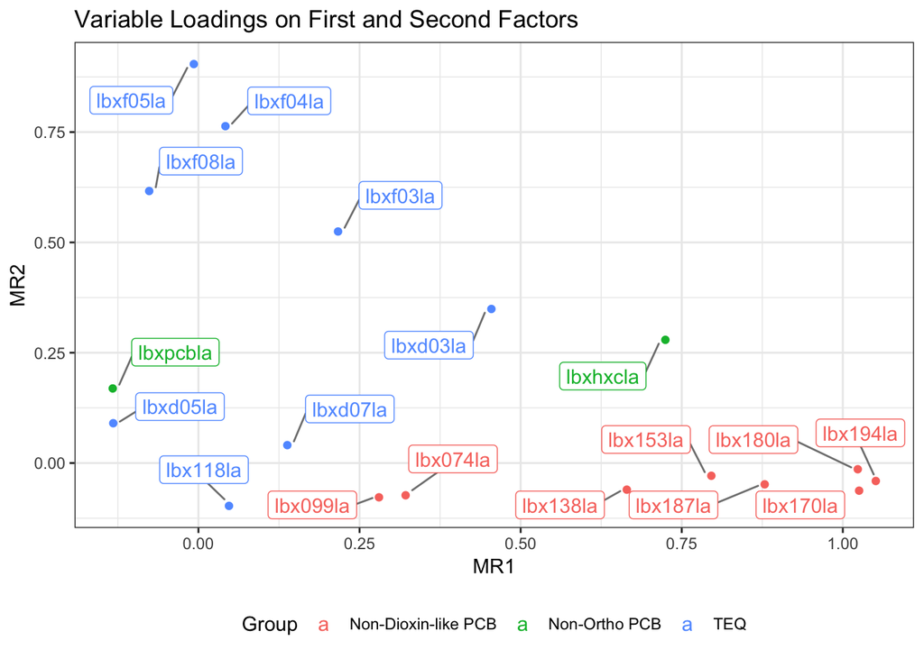

```r
loadings <- loadings %>%
  mutate(Group = ifelse(Variable == "lbx118la", "TEQ",
                        ifelse(grepl("lbx1", Variable), "Non-Dioxin-like PCB",
                               ifelse(grepl("lbx0", Variable), "Non-Dioxin-like PCB",
                                      ifelse(grepl("lbxp", Variable), "Non-Ortho PCB",
                                             ifelse(grepl("lbxh", Variable), "Non-Ortho PCB", "TEQ"))))))

loadings %>%
  ggplot(aes(x = MR1, y = MR2, color = Group)) +
  geom_point() + geom_label_repel(aes(label = Variable),
                                  box.padding   = 0.35,
                                  point.padding = 0.5,
                                  segment.color = 'grey50') +
  theme_bw() + theme(legend.position = "bottom") +
  labs(title = "Variable Loadings on First and Second Factors")
```

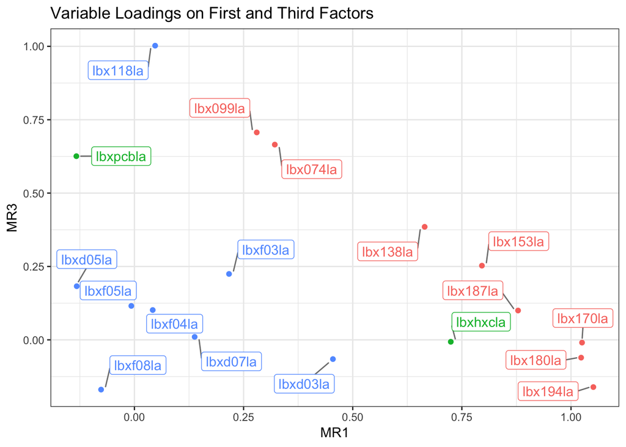

```r
loadings %>%
  ggplot(aes(x = MR1, y = MR3, color = Group)) +
  geom_point() + geom_label_repel(aes(label = Variable),
                                  box.padding   = 0.35,
                                  point.padding = 0.5,
                                  segment.color = 'grey50') +
  theme_bw() + theme(legend.position = "none") +
  labs(title = "Variable Loadings on First and Third Factors")
```

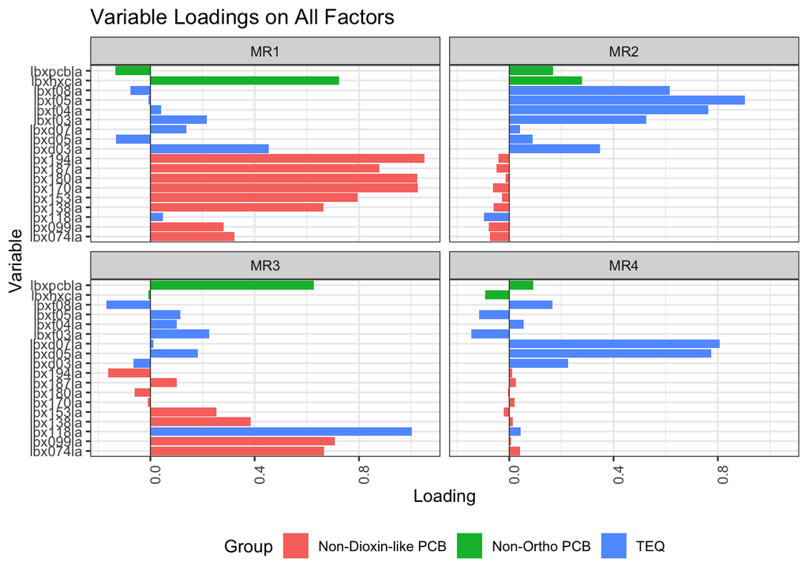

```r
plot_loadings <- loadings %>%
  dplyr::select(-Max) %>%
  gather(key = "Factor", value = "Loading", -Variable, -Group)

plot_loadings %>%
  ggplot(aes(x = Variable, y = Loading, fill = Group)) + geom_col() +
  facet_wrap(~ Factor) + theme_bw() +
  theme(legend.position = "bottom", axis.text.x = element_text(angle = 90, hjust = 1)) +
  coord_flip() + geom_hline(yintercept = 0, size = 0.2) +
  labs(title = "Variable Loadings on All Factors")
```

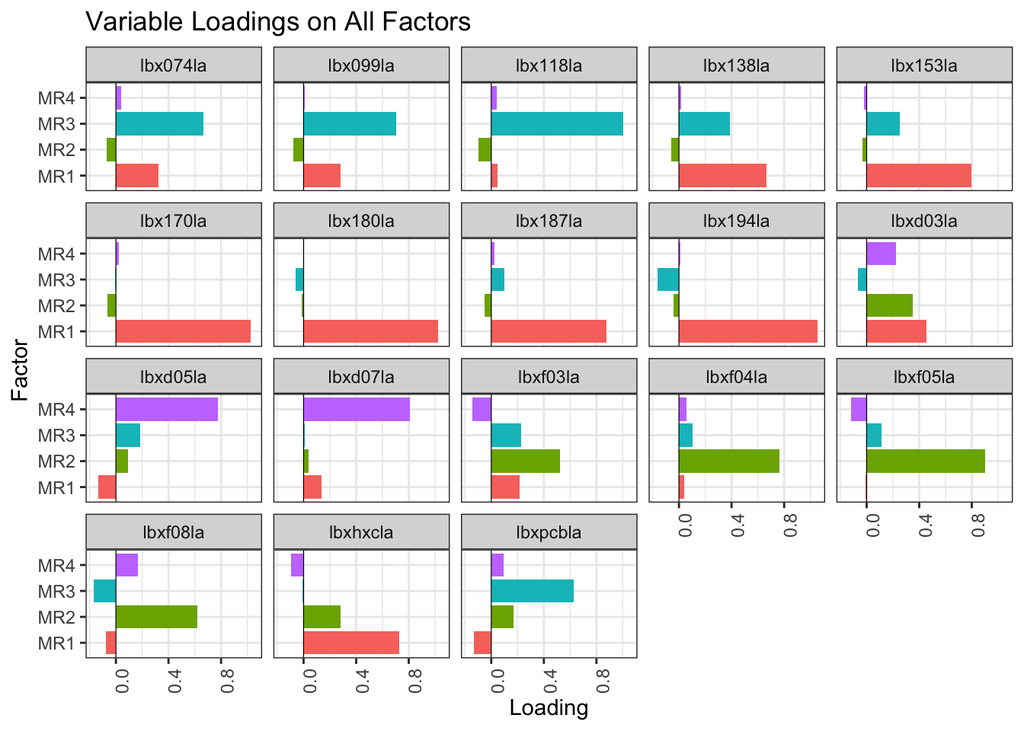

```r
plot_loadings %>%
  ggplot(aes(x = Factor, y = Loading, fill = Factor)) + geom_col(position = "dodge") +
  facet_wrap(~ Variable) +
  theme_bw() + theme(legend.position = "none", axis.text.x = element_text(angle = 90, hjust = 1)) +
  coord_flip() + geom_hline(yintercept = 0, size = 0.2) +
  labs(title = "Variable Loadings on All Factors")
```

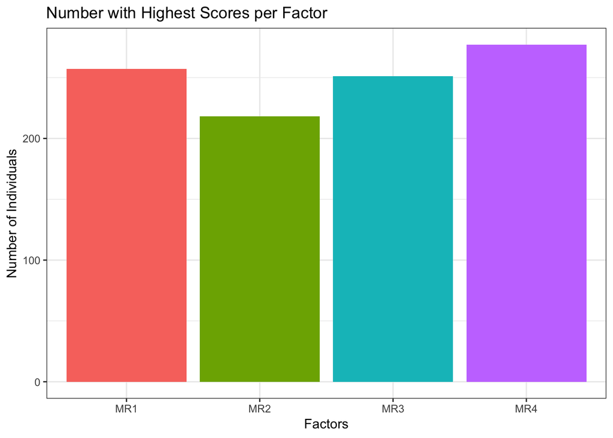

```r
scores %>% ggplot(aes(x = Max, fill = Max)) + geom_bar() +
  labs(x = "Factors", y = "Number of Individuals", title = "Number with Highest Scores per Factor") +
  theme_bw() + theme(legend.position = "none")
```

## Health Models

Combine Factor scores with original data outcome and covariates.

```r
pop <- read_csv("./Data/studypop.csv") %>%
  clean_names() %>%
  na.omit() %>% #remove missing
  dplyr::select(-(3:10), -(17:26)) %>%
  mutate(logtelomean = log(telomean))
pop_fa <- as.tibble(cbind(pop, scores))
```

### Continuous

```r
health_model <- lm(logtelomean ~ MR1  + MR2 +  MR3  +  MR4 + age_cent + age_sq +
     lbxwbcsi + lbxlypct + lbxmopct + lbxnepct + lbxeopct + lbxbapct +
     as.factor(bmi_cat3) + as.factor(edu_cat) + as.factor(race_cat) + male, data = pop_fa)

health_model %>% broom::tidy() %>% mutate(
  estimate = round(estimate, 4),
  std.error = round(std.error, 4),
  statistic = round(statistic, 4),
  p.value = round(p.value, 4))
```

```
##                    term estimate std.error statistic p.value
## 1           (Intercept)   3.0360    8.1009    0.3748  0.7079
## 2                   MR1  -0.0026    0.0147   -0.1747  0.8613
## 3                   MR2   0.0274    0.0117    2.3377  0.0196
## 4                   MR3   0.0283    0.0112    2.5260  0.0117
## 5                   MR4  -0.0205    0.0107   -1.9106  0.0563
## 6              age_cent  -0.0066    0.0007   -9.0480  0.0000
## 7                age_sq   0.0000    0.0000   -0.8394  0.4015
## 8              lbxwbcsi  -0.0050    0.0035   -1.4166  0.1569
## 9              lbxlypct  -0.0291    0.0810   -0.3591  0.7196
## 10             lbxmopct  -0.0343    0.0810   -0.4236  0.6719
## 11             lbxnepct  -0.0284    0.0810   -0.3502  0.7263
## 12             lbxeopct  -0.0283    0.0810   -0.3490  0.7272
## 13             lbxbapct  -0.0108    0.0822   -0.1310  0.8958
## 14 as.factor(bmi_cat3)2  -0.0070    0.0163   -0.4284  0.6684
## 15 as.factor(bmi_cat3)3  -0.0197    0.0180   -1.0989  0.2721
## 16  as.factor(edu_cat)2   0.0171    0.0184    0.9307  0.3522
## 17  as.factor(edu_cat)3   0.0286    0.0177    1.6123  0.1072
## 18  as.factor(edu_cat)4   0.0071    0.0207    0.3430  0.7317
## 19 as.factor(race_cat)2  -0.0299    0.0272   -1.1010  0.2712
## 20 as.factor(race_cat)3   0.0010    0.0285    0.0343  0.9726
## 21 as.factor(race_cat)4  -0.0419    0.0251   -1.6676  0.0957
## 22                 male  -0.0333    0.0147   -2.2646  0.0238
```

```r
health_model %>% broom::glance() %>% mutate(p.value = round(p.value, 5))
```

```
##   r.squared adj.r.squared    sigma statistic p.value df   logLik       AIC
## 1 0.2636311     0.2478679 0.201132  16.72442       0 22 196.5322 -347.0643
##        BIC deviance df.residual
## 1 -234.117 39.68547         981
```

### Categorical

```r
categorical <- lm(logtelomean ~ as.factor(Max) + age_cent + age_sq +
     lbxwbcsi + lbxlypct + lbxmopct + lbxnepct + lbxeopct + lbxbapct +
     as.factor(bmi_cat3) + as.factor(edu_cat) + as.factor(race_cat) + male, data = pop_fa)

categorical %>% broom::tidy() %>% mutate(
  estimate = round(estimate, 4),
  std.error = round(std.error, 4),
  statistic = round(statistic, 4),
  p.value = round(p.value, 4))
```

```
##                    term estimate std.error statistic p.value
## 1           (Intercept)   4.1641    8.1042    0.5138  0.6075
## 2     as.factor(Max)MR2   0.0520    0.0194    2.6734  0.0076
## 3     as.factor(Max)MR3   0.0414    0.0197    2.0969  0.0363
## 4     as.factor(Max)MR4  -0.0184    0.0202   -0.9117  0.3622
## 5              age_cent  -0.0055    0.0005  -10.5392  0.0000
## 6                age_sq   0.0000    0.0000   -1.0357  0.3006
## 7              lbxwbcsi  -0.0052    0.0035   -1.4772  0.1399
## 8              lbxlypct  -0.0405    0.0810   -0.5000  0.6172
## 9              lbxmopct  -0.0456    0.0810   -0.5632  0.5734
## 10             lbxnepct  -0.0398    0.0810   -0.4918  0.6230
## 11             lbxeopct  -0.0396    0.0810   -0.4892  0.6248
## 12             lbxbapct  -0.0244    0.0822   -0.2968  0.7667
## 13 as.factor(bmi_cat3)2  -0.0120    0.0161   -0.7432  0.4575
## 14 as.factor(bmi_cat3)3  -0.0203    0.0175   -1.1577  0.2473
## 15  as.factor(edu_cat)2   0.0192    0.0184    1.0455  0.2961
## 16  as.factor(edu_cat)3   0.0290    0.0177    1.6340  0.1026
## 17  as.factor(edu_cat)4   0.0105    0.0206    0.5090  0.6109
## 18 as.factor(race_cat)2  -0.0344    0.0271   -1.2677  0.2052
## 19 as.factor(race_cat)3   0.0144    0.0280    0.5166  0.6056
## 20 as.factor(race_cat)4  -0.0418    0.0251   -1.6695  0.0953
## 21                 male  -0.0377    0.0142   -2.6598  0.0079
```

```r
categorical %>% broom::glance() %>% mutate(p.value = round(p.value, 5))
```

```
##   r.squared adj.r.squared     sigma statistic p.value df   logLik
## 1 0.2628941     0.2478817 0.2011302  17.51186       0 21 196.0304
##         AIC       BIC deviance df.residual
## 1 -348.0609 -240.0243 39.72519         982
```

## Plot Models

### Continuous

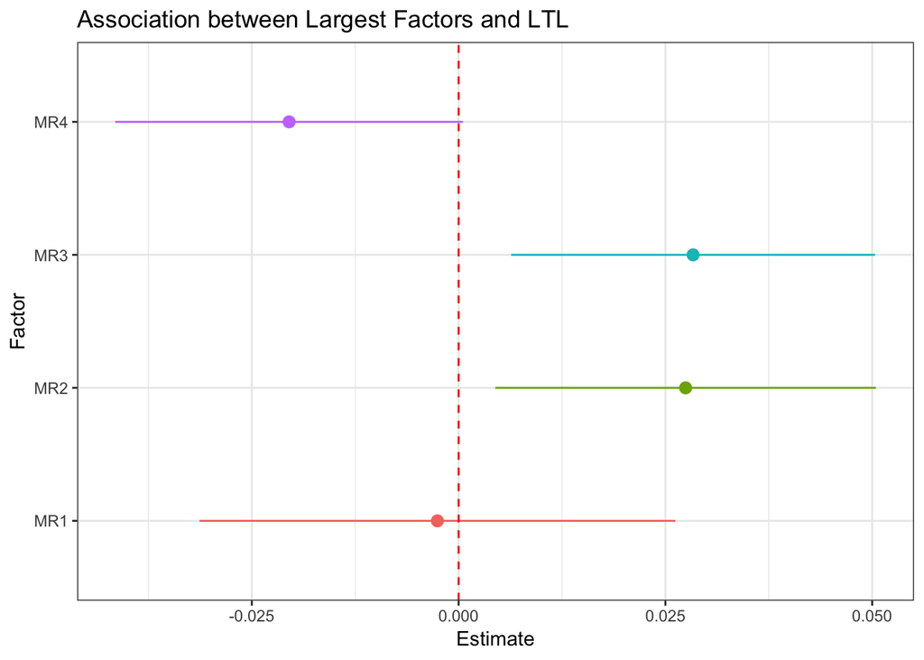

```r
health_model %>% broom::tidy() %>% as.tibble() %>% filter(grepl("MR", term)) %>%
  ggplot(aes(x = term, y = estimate, color = term,
             ymin = estimate - 1.96*std.error,
             ymax = estimate + 1.96*std.error)) +
  geom_pointrange() + theme_bw() +
  geom_hline(yintercept = 0, color = "red", linetype = "dashed") +
  theme(legend.position = "none") + coord_flip() +
  labs(y = "Estimate", x = "Factor", title = "Association between Largest Factors and LTL")
```

### Categorical

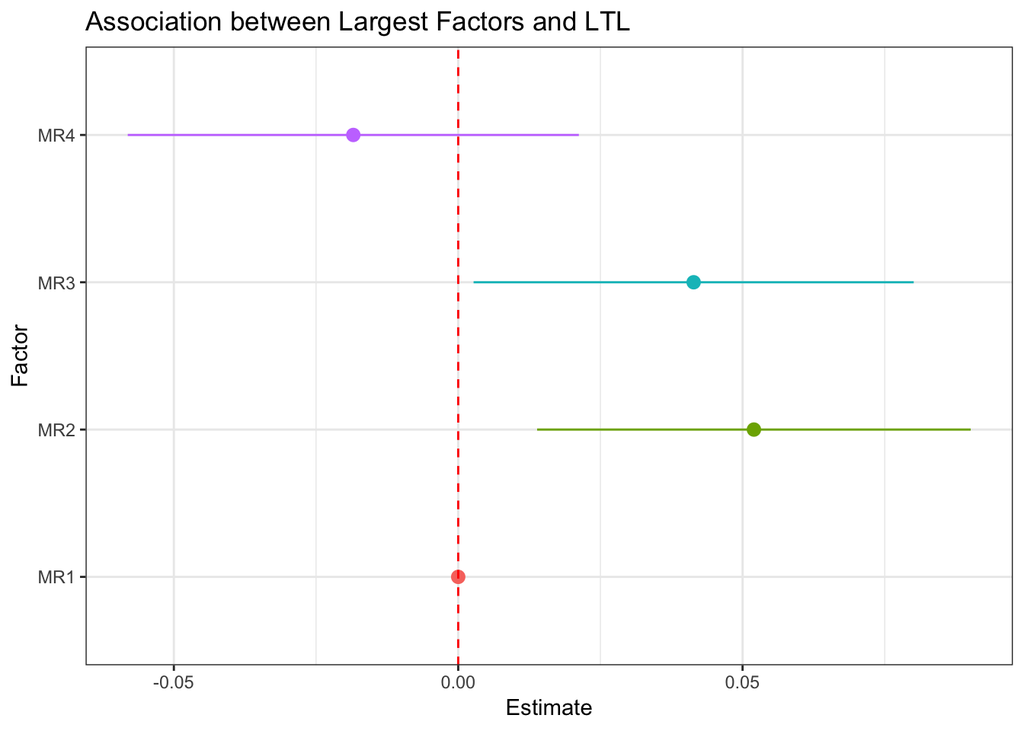

```r
categorical %>% broom::tidy() %>% as.tibble() %>% filter(grepl("MR", term)) %>%
  mutate(term = ifelse(term == "as.factor(Max)MR2", "MR2",
                       ifelse(term == "as.factor(Max)MR3", "MR3", "MR4"))) %>%
  rbind(., c("MR1", 0, 0, 0, 0)) %>%
  mutate(estimate = as.numeric(estimate),
         std.error = as.numeric(std.error)) %>%
  ggplot(aes(x = term, y = estimate, color = term,
             ymin = estimate - 1.96*std.error,
             ymax = estimate + 1.96*std.error)) +
  geom_pointrange() + theme_bw() +
  geom_hline(yintercept = 0, color = "red", linetype = "dashed") +
  theme(legend.position = "none") + coord_flip() +
  labs(y = "Estimate", x = "Factor", title = "Association between Largest Factors and LTL")
```